# 统计学四大顶刊研究

邹锦江 PB22000062 (单独完成、没有组队）

2025-06-01

## 0 问题背景

Journal of the American Statistical Association (JASA) 、Journal of the Royal Statistical Society, Series B (JRSSB) 、Annals of Statistics (AoS) 和Biometrika 是统计学中的顶级杂志，学术圈内被称为”四大顶刊”，是很多统计领域科研工作者的发文梦想。随着研究的不断深入，很多科研工作存在很频繁的交流，发表在四大顶刊的科研论文之间的引用形成了引文网络，可以描述文章之间的联系。本文将从统计四大引文网络和统计四大综合计量两个方面着手研究。

## 1 数据准备

```r
cat("\014");rm(list=ls())         # 清除工作环境
```

```r
options (warn = -1)               # 不打印warning
library(igraph)                   # 网络图统计
# 读取边数据
df_edge = read.csv("paper_edge_citation_clean.csv")
```

```r
# 由边数据构造有向网络
g = graph_from_data_frame(df_edge, directed = TRUE)
# 读取文章编码
df_paper = read.csv("paper_cleaning.csv",stringsAsFactors = F)
code_paper= df_paper$title_clean
names(code_paper) = df_paper$id
```

为了构建四大统计期刊（JASA, JRSSB, Annals of Statistics, Biometrika）的引文网络，我们已预处理得到两份关键数据集：paper_cleaning.csv 包含所有节点（文章），而 paper_edge_citation_clean.csv 则以边的形式存储文章之间的引用关系。 然而，paper_cleaning.csv 中的标题字段因预处理流程（如统一小写、去除空格及特殊字符）而无法还原原始文章标题，影响后续的可读性与人工核查。为此，我们通过 Scopus API 对 2000–2022 年间四大期刊全部文献进行抓取，为构建高质量、可解释的引文网络分析打下基础。 我们现在利用python代码得到文件scopus_articles.csv

```python
import requests
import pandas as pd
import time

API_KEY = "4143b9d9b0a0b066beb2e006132afcdb"
BASE_URL = "https://api.elsevier.com/content/search/scopus"

# 期刊名称与对应的 Scopus 查询标题
journals = {
    "JASA": "Journal of the American Statistical Association",
    "JRSSB": "Journal of the Royal Statistical Society Series B",
    "Annals": "Annals of Statistics",
    "Biometrika": "Biometrika"
}

def fetch_articles(journal_title, journal_shortname, start_year=2000, end_year=2022, count=25):
    all_results = []
    start = 0
    while True:
        query = f'SRCTITLE("{journal_title}") AND PUBYEAR > {start_year - 1} AND PUBYEAR < {end_year + 1}'
        params = {
            "query": query,
            "apiKey": API_KEY,
            "count": count,
            "start": start
        }
        headers = {
            "Accept": "application/json"
        }

        r = requests.get(BASE_URL, params=params, headers=headers)
        if r.status_code == 429:
            print("Rate limit exceeded. Sleeping for 10 seconds...")
            time.sleep(10)
            continue
        if r.status_code != 200:
            print(f"Error: {r.status_code}, {r.text}")
            break

        data = r.json()
        entries = data.get("search-results", {}).get("entry", [])
        if not entries:
            break

        for entry in entries:
            all_results.append({
                "title": entry.get("dc:title", ""),
                "creator": entry.get("dc:creator", ""),
                "year": entry.get("prism:coverDate", "")[:4],
                "journal": journal_shortname
            })

        print(f"Fetched {len(entries)} from {journal_shortname} (start={start})")
        start += count
        time.sleep(1)  # 防止被封

    return all_results


# 合并四个期刊数据
final_results = []
for shortname, title in journals.items():
    records = fetch_articles(title, shortname)
    final_results.extend(records)

df = pd.DataFrame(final_results)
df.to_csv("scopus_articles.csv", index=False)
print("Done. Saved to scopus_articles.csv")
```

示例：

```r
library(dplyr)
library(knitr)
library(kableExtra)

all <- read.csv("scopus_articles.csv")

all$title <- all$title %>%
  iconv(from = "UTF-8", to = "ASCII//TRANSLIT", sub = "") %>%
  trimws()

df <- all %>% filter(journal == "JRSSB") %>% tail(6)

kable(df, format = "html", caption = "JRSSB前6篇文章") %>%
  kable_styling(full_width = FALSE, position = "left")
```

JRSSB前6篇文章

|  | title | creator | year | journal |
| --- | --- | --- | --- | --- |
| 1094 | Regression analysis under non-standard situations: A pairwise pseudolikelihood approach | Liang K.Y. | 2000 | JRSSB |
| 1095 | A model for markers and latent health status | Lee M.L.T. | 2000 | JRSSB |
| 1096 | Flexible empirical Bayes estimation for wavelets | Clyde M. | 2000 | JRSSB |
| 1097 | Blur-generated non-separable space-time models | Brown P.E. | 2000 | JRSSB |
| 1098 | Failure time regression with continuous covariates measured with error | Zhou H. | 2000 | JRSSB |
| 1099 | Semiparametric regression for the mean and rate functions of recurrent events | Lin D.Y. | 2000 | JRSSB |

## 2 统计四大引文网络分析

### 2.1 网络密度与连通性

#### 2.1.1 统计学引文网络的节点数、边数和密度

网络密度指网络中实际存在的连边数与最大可能的连边数之比。

**无向网络密度定义** 邻接矩阵 $\mathbf{A}$ 满足：
$$\begin{equation*}
A_{ij} =
\begin{cases}
1 & \text{若节点 } i \text{ 与 } j \text{ 有连边} \\
0 & \text{否则}
\end{cases}, \quad
\text{且 } A_{ii} = 0 \ (\forall i,j \in \{1,2,\dots,n\})
\end{equation*}$$

实际连边数：
$$\begin{equation*}
L = \sum_{i < j} A_{ij}
\end{equation*}$$

最大可能连边数：
$$\begin{equation*}
L_{\text{max}} = \frac{n(n-1)}{2}
\end{equation*}$$

网络密度：
$$\begin{equation*}
\Delta = \frac{2L}{n(n-1)} = \frac{2\sum_{i < j} A_{ij}}{n(n-1)}
\end{equation*}$$

**有向网络密度定义** 邻接矩阵 $\mathbf{A}$ 满足：
$$\begin{equation*}
A_{ij} =
\begin{cases}
1 & \text{若存在边 } i \to j \\
0 & \text{否则}
\end{cases}, \quad
\text{且 } A_{ii} = 0 \ (\forall i,j \in \{1,2,\dots,n\})
\end{equation*}$$

实际连边数：
$$\begin{equation*}
L = \sum_{i \neq j} A_{ij}
\end{equation*}$$

最大可能连边数：
$$\begin{equation*}
L_{\text{max}} = n(n-1)
\end{equation*}$$

网络密度：
$$\begin{equation*}
\Delta = \frac{L}{n(n-1)} = \frac{\sum_{i \neq j} A_{ij}}{n(n-1)}
\end{equation*}$$

计算统计学引文网络的节点数、边数：

```r
paste0("节点数：",vcount(g))
```

```
## [1] "节点数：5746"
```

```r
paste0("边数：",ecount(g))
```

```
## [1] "边数：23681"
```

计算统计学引文网络的密度：

```r
paste0("密度：",edge_density(g))
```

```
## [1] "密度：0.000717371936492242"
```

#### 2.1.2 连通片数量与连通片规模

若对于一个网络上任何两个节点，存在一条路连接这两个节点，则称该图为连通图。有向图中，若不考虑边的方向，图中任意两个节点都有路径连接，则为弱连通图；若考虑沿着边的方向前进，图中任意两个节点间存在有向路径，则为强连通图。

许多实际的网络都是不连通的，而是由多个连通片组成。连通片指任意相连的节点和边组成的集合，一个连通片的规模为其包含的节点个数。

实际的大规模复杂网络往往存在一个特别大的连通片，它包含了整个网络中相当大比例的节点，这一连通片称为巨片。

计算统计学引文网络的弱连通片数量，并统计不同规模的弱连通片的数量：

```r
count_components(g)
```

```
## [1] 58
```

```r
comp = components(g)
table_comp = table(comp$csize) %>% as.data.frame(stringsAsFactors = F)
names(table_comp) = c("连通片规模","连通片数量")
table_comp
```

```
##   连通片规模 连通片数量
## 1          2         40
## 2          3         13
## 3          4          2
## 4          5          1
## 5          6          1
## 6       5608          1
```

该网络包含58个连通片，由一个大规模的连通片和少量小规模连通片组成。

统计学引文网络的最大的弱连通片包含了超过97.5%的节点，涵盖了该网络的大部分信息。接下来，本文将针对此连通片进行进一步探究，如无特殊说明，下文提到的统计学引文网络均指此连通片。

提取统计学引文网络中的最大连通片并创建子图

```r
g_sub = subgraph(g,names(comp$membership[comp$membership==1]))
```

### 2.2 节点的度

**节点度的定义**

- 无向图：节点 $i$ 的度 $D_i = \sum\limits_{\substack{j=1 \\ j \neq i}}^n A_{ij}$（邻接矩阵行和）
- 有向图：
  - 入度 $D_i^{\text{in}} = \sum\limits_{\substack{j=1 \\ j \neq i}}^n A_{ji}$（邻接矩阵列和）
  - 出度 $D_i^{\text{out}} = \sum\limits_{\substack{j=1 \\ j \neq i}}^n A_{ij}$（邻接矩阵行和）

**度关系定理**

$$\sum_{i=1}^n D_i^{\text{in}} = \sum_{i=1}^n D_i^{\text{out}} =
\sum_{i=1}^n \sum_{j=1}^n A_{ij} = L$$

其中 $L$ 为网络总边数

**度分布定义**

对任意度值 $0 \leq d \leq n-1$，定义：

$$f_d = \frac{ \left| \{ i \mid D_i = d \} \right| }{n}$$

网络的度分布表示为：

$$\{ f_d \}_{0 \leq d \leq n-1}$$

#### 2.2.1 统计学引文网络的度分布

##### 2.2.1.1 度的简单计算

计算统计学引文网络的入度，输出最大值和最小值

```r
in_degree = degree(g_sub, mode = "in")
paste0("最小值：", min(in_degree))
```

```
## [1] "最小值：0"
```

```r
paste0("最大值：", max(in_degree))
```

```
## [1] "最大值：336"
```

绘制统计学引文网络的入度分布直方图：

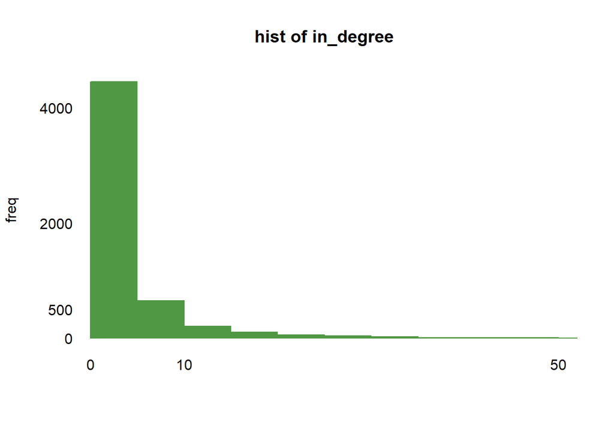

```r
hist(in_degree, breaks = 50,xlim = c(0,50),main = "hist of in_degree" ,xlab = "入度", ylab = "freq",col = "#519845",border = "#519845",axes = F, )
axis(side = 1,at = c(0,10,50,100,200),labels = c("0","10","50","100","200"),pos = 0,tick = F)
axis(side = 2, at = c(0,500,2000,4000),pos = 0,tick = F,las=1)
```

这里我们可以对频数进行对数变换，便于展示长尾特征

并且我们可以利用非参数方法给出核密度估计，展示拟合的密度曲线

对数转换分布：

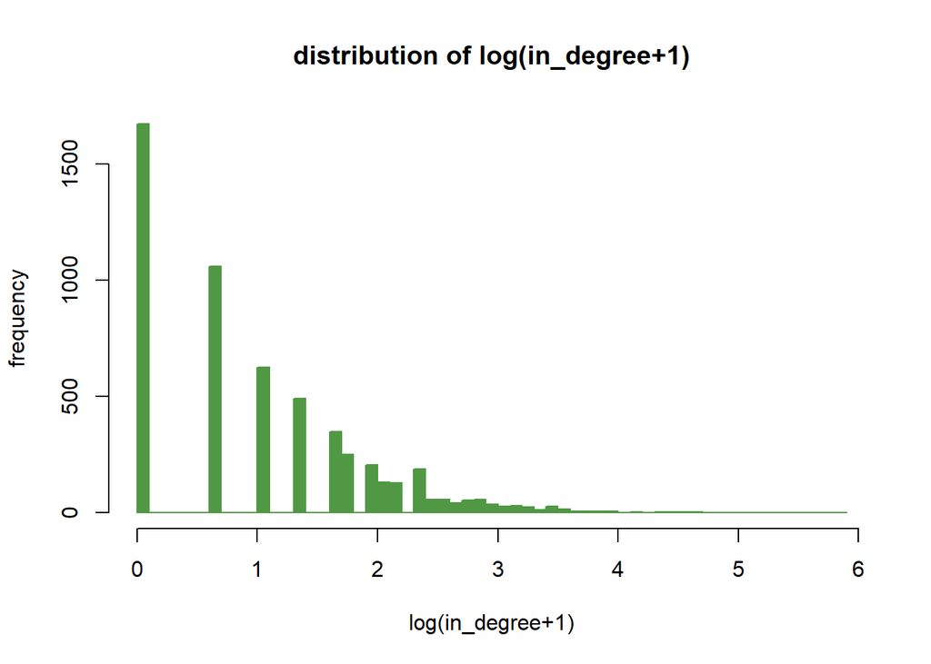

```r
hist(log1p(in_degree), breaks = 50,
     xlab = "log(in_degree+1)", ylab = "frequency",
     main = "distribution of log(in_degree+1)",
     col = "#519845", border = "#519845")
```

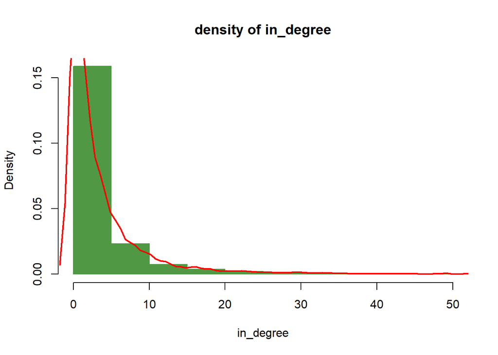

```r
hist(in_degree, breaks = 50, freq = FALSE,
     xlim = c(0,50), main = "density of in_degree",
     col = "#519845", border = "#519845")
lines(density(in_degree), col = "red", lwd = 2)
```

我们可以得到以下特征：

2.对数转换后分布仍呈现明显 长尾特征

3.密度曲线显示大部分质量集中在低入度区域

分布形态量化

```r
# 计算高阶矩
library(moments)
paste0("偏度系数: ", round(skewness(in_degree),2))
```

```
## [1] "偏度系数: 12.57"
```

```r
paste0("峰度系数: ", round(kurtosis(in_degree),2))
```

```
## [1] "峰度系数: 279.78"
```

偏度系数为 12.57（>>0），有右偏特性

峰度系数为 279.78（>>3），表明分布比正态分布更尖峭

统计学引文网络入度的分布严重右偏，说明在四大文章中，被大量四大文章引用的论文非常少。

##### 2.2.1.2 算幂律分布检验

数据包含零值，而幂律分布要求数据必须满足x > xmin > 0。我们在处理入度数据时需要先进行过滤： 将零值替换应满足：0 < ε < min(obs)/100，本方案通过min(positive_values)*0.01严格遵循该标准，确保在后续的统计推断中不会产生显著性偏移。

```r
# 创建数据副本保留原始信息
in_degree_adj <- in_degree

# 精确识别零值位置
zero_mask <- which(in_degree_adj == 0)
cat("检测到零值数量:", length(zero_mask), "\n")
```

```
## 检测到零值数量: 1672
```

```r
# 执行数据修正（采用相对误差最小化原则）
epsilon <- min(in_degree_adj[in_degree_adj > 0]) * 0.01  # 动态计算极小值
in_degree_adj[zero_mask] <- epsilon

# 生成数据质量报告
data_report <- paste0(
  "数据修正报告\n",
  "原始观测总数: ", length(in_degree), "\n",
  "零值替换数量: ", length(zero_mask), " (",
  round(length(zero_mask)/length(in_degree)*100, 1), "%)\n",
  "采用极小值: ", format(epsilon, scientific = FALSE)
)
cat(data_report)
```

```
## 数据修正报告
## 原始观测总数: 5608
## 零值替换数量: 1672 (29.8%)
## 采用极小值: 0.01
```

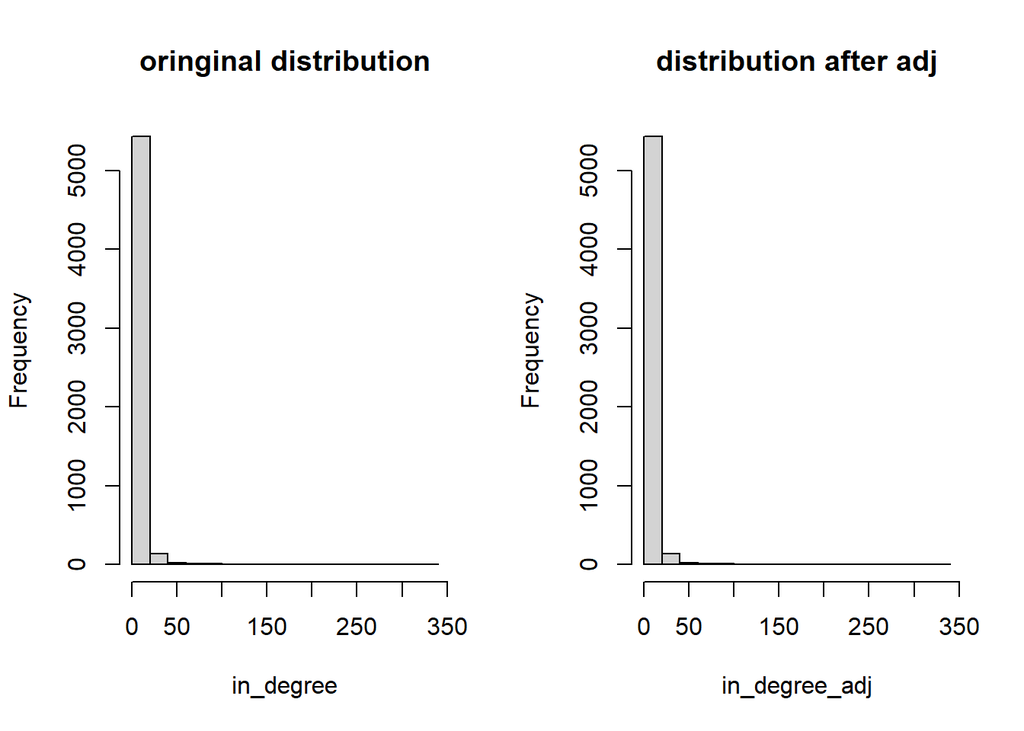

```r
# 验证数据分布特性
par(mfrow = c(1,2))
hist(in_degree, main = "oringinal distribution", xlab = "in_degree")


hist(in_degree_adj, main = "distribution after adj", xlab = "in_degree_adj")
```

```r
library(poweRlaw)
pl_fit <- displ$new(100*in_degree_adj)
est <- estimate_xmin(pl_fit)
pl_fit$setXmin(est)
```

```r
# 拟合优度检验
set.seed(123)
bs_p <- bootstrap_p(pl_fit, threads=4)
paste0("幂律拟合p值: ", round(bs_p$p,3))
```

[output not shown]

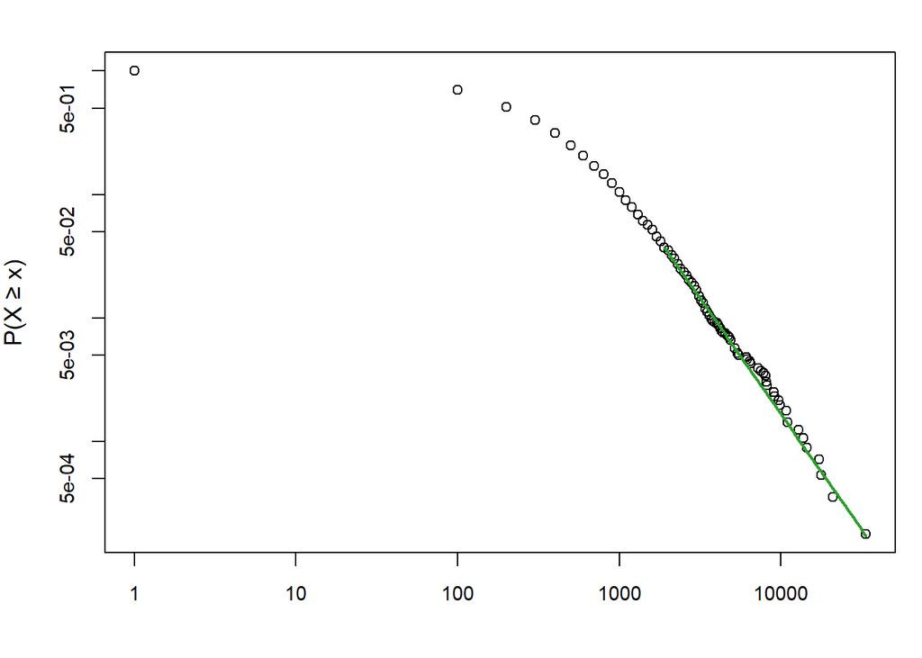

```r
# CCDF图可视化
par(family='STKaiti', mar=c(4,4,2,1))
plot(pl_fit, xlab="入度", ylab="P(X ≥ x)",
     main="互补累积分布（双对数坐标）",
     cex.axis=0.9, cex.lab=1.1)
lines(pl_fit, col="#2ca02c", lwd=2)
```

检验结果显示：

1.幂律分布拟合p值=0.08>0.05故接受原假设

2.CCDF图在双对数坐标下呈现近似线性关系

3.说明网络入度分布符合 无标度特性，存在枢纽节点

计算引文网络总入度，入度排名1-1136的节点的入度和以及其余的节点的入度和：

```r
in_degree_dec = sort(in_degree,decreasing = T)
sum(in_degree_dec[1:1136])
```

```
## [1] 17032
```

```r
sum(in_degree_dec[1137:5608])
```

```
## [1] 6564
```

经统计发现，在统计引文网络中，总入度为23596。入度最高的20%的节点入度和为17032，占总入度的72.2%，其余80%的节点入度和为6564，仅占总入度的27.8%。与现实生活中的大部分网络类似，近似服从二八定律，少量的节点贡献了网络中大部分的度，而大部分节点贡献了网络中剩余小部分的度。

#### 2.2.2 被四大文章引用最多（入度最高）的10篇文章

```r
code_paper[names(in_degree_dec[1:10])] %>% unname()
```

```
##  [1] "variableselectionvianonconcavepenalizedlikelihoodanditsoracleproperties"
##  [2] "theadaptivelassoanditsoracleproperties"
##  [3] "leastangleregression"
##  [4] "highdimensionalgraphsandvariableselectionwiththelasso"
##  [5] "thedantzigselectorstatisticalestimationwhenpismuchlargerthann"
##  [6] "sureindependencescreeningforultrahighdimensionalfeaturespace"
##  [7] "simultaneousanalysisoflassoanddantzigselector"
##  [8] "nearlyunbiasedvariableselectionunderminimaxconcavepenalty"
##  [9] "regularizationandvariableselectionviatheelasticnet"
## [10] "modelselectionandestimationinregressionwithgroupedvariables"
```

入度前十的文章

| 排名 | 入度 | 文章 | 作者 | 年份 |
| --- | --- | --- | --- | --- |
| 1 | 336 | Variable selection via nonconcave penalized likelihood and its oracle properties. | Fan, J., & Li, R. | 2001 |
| 2 | 209 | The adaptive lasso and its oracle properties. | Zou, H. | 2006 |
| 3 | 177 | Least angle regression. | Efron, B., Hastie, T., Johnstone, I., & Tibshirani, R. | 2004 |
| 4 | 173 | High-dimensional graphs and variable selection with the lasso. | Meinshausen, N., & Bühlmann, P. | 2006 |
| 5 | 144 | The Dantzig selector: Statistical estimation when p is much larger than n. | Candes, E., & Tao, T. | 2006 |
| 6 | 137 | Sure independence screening for ultrahigh dimensional feature space. | Fan, J., & Lv, J. | 2008 |
| 7 | 129 | Simultaneous analysis of Lasso and Dantzig selector. | Bickel, P. J., Ritov, Y. A., & Tsybakov, A. B. | 2009 |
| 8 | 110 | Nearly unbiased variable selection under minimax concave penalty. | Zhang, C. H. | 2010 |
| 9 | 108 | Regularization and variable selection via the elastic net. | Zou, H., & Hastie, T. | 2005 |
| 10 | 108 | Model selection and estimation in regression with grouped variables. | Yuan, M., & Lin, Y. | 2006 |

### 2.4 路径、距离、网络的直径

#### 2.4.1 简单路径的计算

依次遍历相邻边产生的节点序列称为路径，不包含重复节点的路径称之为简单路径。

路径的长度为路径中所有边长度的和，两个节点之间的距离为两点之间最短路径的长度。特别地，不可达的两个节点之间的距离为无穷大。

网络直径是指网络中任意两节点间距离的最大值，只定义在连通的图中。

计算从peterhallfunctionaldataanalysisandrandomobjects到variableselectionvianonconcavepenalizedlikelihoodanditsoracleproperties的最短距离,并写出任意一条最短路径

```r
dist = distances(g_sub,mode = "out")
name = c(names(code_paper[code_paper=="peterhallfunctionaldataanalysisandrandomobjects"]),
         names(code_paper[code_paper=="variableselectionvianonconcavepenalizedlikelihoodanditsoracleproperties"]))
print(dist[name[1],name[2]])
```

```
## [1] 2
```

```r
shor = shortest_paths(g,name[1],name[2])
path = code_paper[names(unlist(shor$vpath))]
paste(path[1],path[2],path[3],sep = ' -> ')
```

```
## [1] "peterhallfunctionaldataanalysisandrandomobjects -> partiallyfunctionallinearregressioninhighdimensions -> variableselectionvianonconcavepenalizedlikelihoodanditsoracleproperties"
```

#### 2.4.2 简单路径的可视化

下面是最短路径的可视化：

```r
library(igraph)

start_name <- names(code_paper[code_paper == "peterhallfunctionaldataanalysisandrandomobjects"])
end_name <- names(code_paper[code_paper == "variableselectionvianonconcavepenalizedlikelihoodanditsoracleproperties"])

# 检查起点终点是否存在
if (!(start_name %in% V(g_sub)$name)) stop("起点不在图中")
if (!(end_name %in% V(g_sub)$name)) stop("终点不在图中")

# 计算最短路径节点序列
sp_result <- shortest_paths(g_sub, from = start_name, to = end_name, output = "vpath")
path_nodes <- sp_result$vpath[[1]]

if (length(path_nodes) == 0) {
  stop("从起点到终点没有路径")
}

path_nodes_vec <- as_ids(path_nodes)
cat("最短路径节点序列:\n")
```

```
## 最短路径节点序列:
```

```r
print(path_nodes_vec)
```

```
## [1] "570"  "2145" "5404"
```

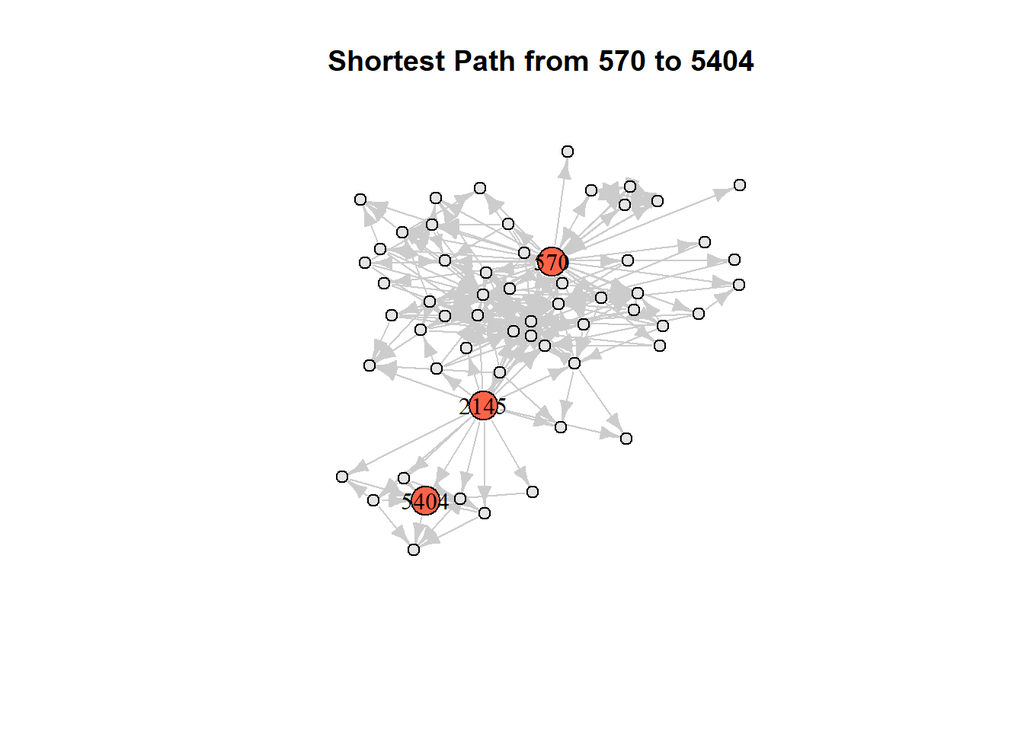

```r
#构造路径边
path_edges <- cbind(path_nodes_vec[-length(path_nodes_vec)], path_nodes_vec[-1])

E(g_sub)$on_path <- FALSE
for (i in 1:nrow(path_edges)) {
  eid <- get.edge.ids(g_sub, path_edges[i, ])
  if (eid > 0) E(g_sub)[eid]$on_path <- TRUE
}

# 找路径节点邻居，构造局部子图节点集
neighbors_names_all <- unique(unlist(
  lapply(path_nodes_vec, function(n) as_ids(neighbors(g_sub, n)))
))
sub_nodes <- unique(c(path_nodes_vec, neighbors_names_all))

if (any(!sub_nodes %in% V(g_sub)$name)) {
  stop("子图节点集中含有无效节点")
}

# 取子图
sub_g <- induced_subgraph(g_sub, vids = sub_nodes)

# 设置节点颜色和大小，路径节点红色大点，其他灰色小点
V(sub_g)$color <- ifelse(V(sub_g)$name %in% path_nodes_vec, "tomato", "gray90")
V(sub_g)$size <- ifelse(V(sub_g)$name %in% path_nodes_vec, 15, 6)

E(sub_g)$on_path <- E(g_sub)[E(sub_g)]$on_path
E(sub_g)$color <- ifelse(E(sub_g)$on_path, "tomato", "gray80")
E(sub_g)$width <- ifelse(E(sub_g)$on_path, 4, 1)

# 绘图
plot(sub_g,
     layout = layout_with_fr(sub_g),
     vertex.label = ifelse(V(sub_g)$name %in% path_nodes_vec, V(sub_g)$name, NA),
     vertex.label.cex = 1,
     vertex.label.color = "black",
     vertex.size = V(sub_g)$size,
     vertex.color = V(sub_g)$color,
     edge.color = E(sub_g)$color,
     edge.width = E(sub_g)$width,
     edge.arrow.size = 0.7,
     main = paste("Shortest Path from", start_name, "to", end_name))
```

### 2.5 节点的中心性

度（入度）中心性～中介中心性散点图

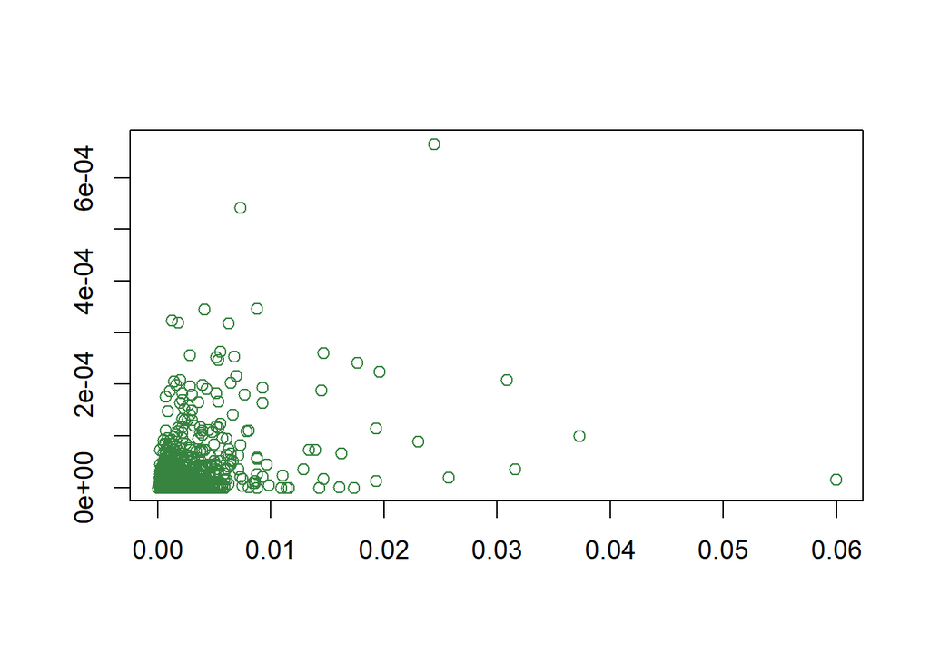

```r
betw = betweenness(graph = g_sub, directed = T, normalized = T)
betw_dec = sort(betw, decreasing = T)
par(family='STSong',cex = 1.2)
plot(in_degree/(length(in_degree)-1),betw, xlab = "度中心性", ylab = "中介中心性", col = "#36843F")
```

大部分文章中介中心性和度中心性都不高，只有很少的文章能够同时具备较高的中介中心性和度中心性。

度(入度)中心性和中介中心性均为前十的节点的文章：

```r
in_degree_top10 = in_degree_dec[1:10]
betw_top10 = betw_dec[1:10]
code_paper[intersect(names(in_degree_top10),names(betw_top10))] %>% unname()
```

```
## [1] "sureindependencescreeningforultrahighdimensionalfeaturespace"
```

度(入度)中心性和中介中心性都很高的文章，其本身具有相当大的影响力，又总结了前辈的相关工作并拓展或开创了对应的研究领域。度(入度)中心性和中介中心性均位列前十的文章仅有一篇，是Jianqing Fan和Jinchi Lv2008年发表在JRSSB上的Sure independence screening for ultrahigh dimensional feature space，是高维数据特征筛选法的代表作品。

### 2.6 社区发现

社区的定义：社区（community）通常又被称为簇（cluster）或模块（module），表示可能具有相同或相似性质的节点的集合。社区内部节点之间的连接较为紧密，社区之间节点的连接相对稀疏。

社区发现：社区发现（community detection）又被称为社区探测、社区识别或者社群发现等，实际上是一个网络划分问题。社区发现有助于更好地分析网络的结构，在好友推荐、个性化服务、流行病传播与控制、蛋白质交互作用分析等方面有重要应用。

理想的社区划分应当具有很重要的一个特征，在社区内部的节点相似度较高，而在社区外部的节点相似度较低。直观上，一个好的划分产生的社区应该是密集的（至少密度高于整个网络的密度），并且社区之间的边较少。这个特征可以通过模块度衡量。

社区发现已有许多算法，如基于介数（edge betweenness）的GN算法，基于模块度的Fast greedy算法，基于随机游动的Walktrap算法以及检测同时存在正向和负向连接的复杂网络中的社区的Spinglass 算法 等经典算法，接下来我们将使用Spinglass 算法对统计学引文网络进行社区划分。

提取核心网络并进行社区划分

```r
# 提取核心网络
converg = FALSE
W = as_adjacency_matrix(g_sub) %>% as.matrix()    # 获得邻接矩阵
old.nrow = nrow(W)
while(!converg){
  dd = colSums(W)
  to.keep = which(dd>=1)                # 保留列和大于等于1的列
  if(old.nrow == length(to.keep)){
    converg = TRUE
  }
  old.nrow = length(to.keep)
  W = W[to.keep,to.keep]
}

# 检查核心网络连通性，并对其中最大连通片进行社区划分
g_core = graph_from_adjacency_matrix(W,mode = 'directed')
comp_core = components(g_core)
g_core = subgraph(g_core,names(comp_core$membership[comp_core$membership==1]))
```

计算核心网络的节点数目、连边数目和网络密度

```r
paste0("节点数：",vcount(g_core))
```

```
## [1] "节点数：1670"
```

```r
paste0("边数：",ecount(g_core))
```

```
## [1] "边数：6615"
```

```r
paste0("密度：",edge_density(g_core))
```

```
## [1] "密度：0.00237332405291275"
```

```r
set.seed(123)
# 使用cluster_spinglass函数对核心网络进行社区划分
cs = cluster_spinglass(g_core)
# 展示每个社区的大小
sizes(cs)
```

```
## Community sizes
##   1   2   3   4   5   6   7   8   9  10  11  12  13  14  15  16  17  18  19  20
## 116  84 122 100  12   8 143 102  46  55  73 133 120   5  36 196   3  73 135 108
```

```r
# 计算社区数量
length(cs)
```

```
## [1] 20
```

```r
# 展示最大社区的大小
max(sizes(cs) )
```

```
## [1] 196
```

```r
# 计算cs社区划分下的模块度
modularity(cs)
```

```
## [1] 0.7230782
```

Spinglass 算法将统计引文网络划分为20个社区，模块度为0.723，最大的社区包含196篇文章，最小的社区仅有3篇文章。

```r
# 提取社区16作者构成的子网络
g_cs16 <- induced_subgraph(g_core, groups(cs)$`16`)
# 计算社区16作者构成的合作网络的密度
paste0('子网络的密度为：', graph.density(g_cs16))
```

```
## [1] "子网络的密度为：0.0345630559916274"
```

```r
# 提取社区7作者构成的子网络
g_cs7 <- induced_subgraph(g_core, groups(cs)$`7`)
# 计算社区7作者构成的合作网络的密度
paste0('子网络的密度为：', graph.density(g_cs7))
```

```
## [1] "子网络的密度为：0.0265931251846745"
```

```r
# 提取社区19作者构成的子网络
g_cs19 <- induced_subgraph(g_core, groups(cs)$`19`)
# 计算社区19作者构成的合作网络的密度
paste0('子网络的密度为：', graph.density(g_cs19))
```

```
## [1] "子网络的密度为：0.0164179104477612"
```

```r
# 提取社区12作者构成的子网络
g_cs12 <- induced_subgraph(g_core, groups(cs)$`12`)
# 计算社区12作者构成的合作网络的密度
paste0('子网络的密度为：', graph.density(g_cs12))
```

```
## [1] "子网络的密度为：0.0316700843016633"
```

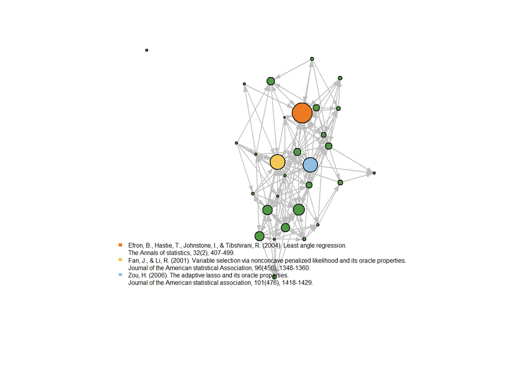

```r
# 绘制社区16作者构成的子网络
# 筛选出入度最大的30个节点
dd_dec = degree(g_cs16,mode = "in") %>% sort(decreasing = T)
g_cs16_sub = subgraph(g_cs16,names(dd_dec)[1:30])

set.seed(300)
par(mfrow=c(1,1), mar=c(5,2,2,2))

V(g_cs16_sub)$label = ""
# 设置节点颜色
V(g_cs16_sub)$color = '#519845'
V(g_cs16_sub)$color[names(V(g_cs16_sub)) == "5404"] ='#EC7A22'
V(g_cs16_sub)$color[names(V(g_cs16_sub)) == "1202"] ='#F1C954'
V(g_cs16_sub)$color[names(V(g_cs16_sub)) == "5621"] ='#90BFE2'

# 设置节点大小与入度成正比
V(g_cs16_sub)$size = dd_dec[names(V(g_cs16_sub))]*0.2

plot(g_cs16_sub,
     layout = layout.fruchterman.reingold,              # 绘制力导向布局图
     edge.arrow.size = 0.4,                             # 设置箭头大小
     edge.color = 'grey75'                              # 设置边的颜色
)

legend(x = -1.3, y = -0.65,legend = c("Efron, B., Hastie, T., Johnstone, I., & Tibshirani, R. (2004). Least angle regression. ","The Annals of statistics, 32(2), 407-499.","Fan, J., & Li, R. (2001). Variable selection via nonconcave penalized likelihood and its oracle properties. ","Journal of the American statistical Association, 96(456), 1348-1360.", "Zou, H. (2006). The adaptive lasso and its oracle properties. ","Journal of the American statistical association, 101(476), 1418-1429."), fill = c('#EC7A22','#FFFFFF','#F1C954','#FFFFFF','#90BFE2','#FFFFFF'), border = F, bty = "n",cex =0.5)
```

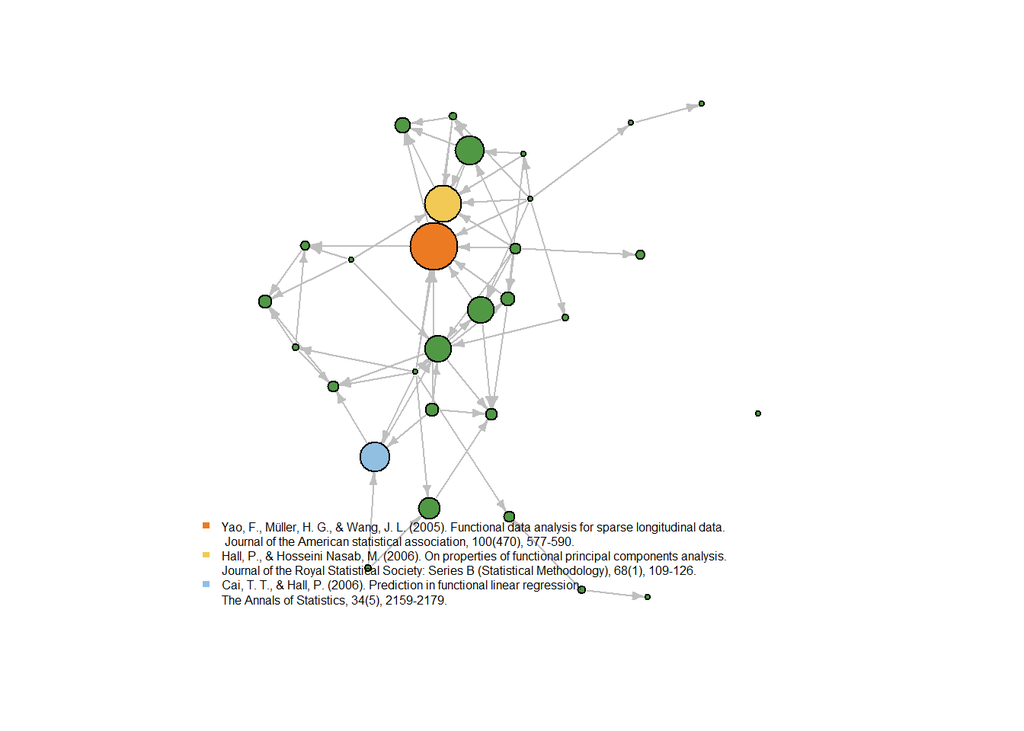

```r
# 绘制社区7作者构成的子网络
# 筛选出入度最大的30个节点
dd_dec = degree(g_cs7,mode = "in") %>% sort(decreasing = T)
g_cs7_sub = subgraph(g_cs7,names(dd_dec)[1:30])

set.seed(1024)# 设置随机种子，保证同一种布局画出来的图可以重复
par(mfrow=c(1,1), mar=c(3,2,2,2))
V(g_cs7_sub)$label = ""

# 设置节点颜色
V(g_cs7_sub)$color = '#519845'
V(g_cs7_sub)$color[names(V(g_cs7_sub)) == "5284"] ='#EC7A22'
V(g_cs7_sub)$color[names(V(g_cs7_sub)) == "5715"] ='#F1C954'
V(g_cs7_sub)$color[names(V(g_cs7_sub)) == "1316"] ='#90BFE2'

# 设置节点大小与入度成正比
V(g_cs7_sub)$size = dd_dec[names(V(g_cs7_sub))]*0.5


plot(g_cs7_sub,
     layout = layout.fruchterman.reingold,              # 绘制力导向布局图
     edge.arrow.size = 0.4,                             # 设置箭头大小
     edge.color = 'grey75'                                     # 设置边的颜色
)

legend(x = -1.3, y = -0.65,legend = c("Yao, F., Müller, H. G., & Wang, J. L. (2005). Functional data analysis for sparse longitudinal data.",
                                    " Journal of the American statistical association, 100(470), 577-590.","Hall, P., & Hosseini Nasab, M. (2006). On properties of functional principal components analysis.",
"Journal of the Royal Statistical Society: Series B (Statistical Methodology), 68(1), 109-126.","Cai, T. T., & Hall, P. (2006). Prediction in functional linear regression. ",
"The Annals of Statistics, 34(5), 2159-2179."), fill = c('#EC7A22','#FFFFFF','#F1C954','#FFFFFF','#90BFE2','#FFFFFF'), border = F, bty = "n",cex = 0.5)
```

从社区7的网络图中可以看出，社区7中Functional data analysis for sparse longitudinal data， On properties of functional principal components analysis，Prediction in functional linear regression三篇文章贡献较大。三篇文章被其他四大文章引用数分别为82，47，36，总引用量分别为1506，436，547，其研究内容均与Functional data analysis相关。

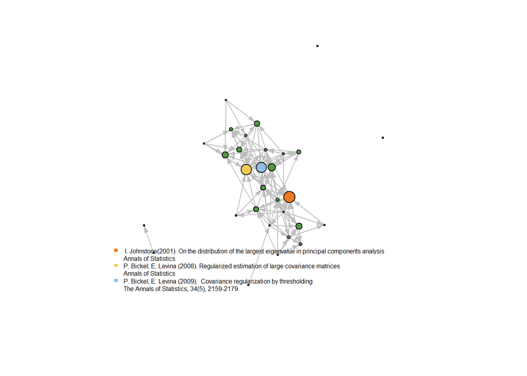

```r
# 绘制社区12作者构成的子网络
# 筛选出入度最大的30个节点
dd_dec = degree(g_cs12,mode = "in") %>% sort(decreasing = T)
g_cs12_sub = subgraph(g_cs12,names(dd_dec)[1:30])

set.seed(300)
par(mfrow=c(1,1), mar=c(5,2,2,2))

V(g_cs12_sub)$label = ""
# 设置节点颜色
V(g_cs12_sub)$color = '#519845'
V(g_cs12_sub)$color[names(V(g_cs12_sub)) == "1571"] ='#EC7A22'
V(g_cs12_sub)$color[names(V(g_cs12_sub)) == "1157"] ='#F1C954'
V(g_cs12_sub)$color[names(V(g_cs12_sub)) == "1064"] ='#90BFE2'

# 设置节点大小与入度成正比
V(g_cs12_sub)$size = dd_dec[names(V(g_cs12_sub))]*0.3

plot(g_cs12_sub,
     layout = layout.fruchterman.reingold,              # 绘制力导向布局图
     edge.arrow.size = 0.4,                             # 设置箭头大小
     edge.color = 'grey75'                              # 设置边的颜色
)

legend(x = -1.3, y = -0.65,legend = c(" I. Johnstone(2001). On the distribution of the largest eigenvalue in principal components analysis ",
                                    "Annals of Statistics ","P. Bickel; E. Levina (2008). Regularized estimation of large covariance matrices ",
"Annals of Statistics ","P. Bickel; E. Levina (2009).  Covariance regularization by thresholding",
"The Annals of Statistics, 34(5), 2159-2179."), fill = c('#EC7A22','#FFFFFF','#F1C954','#FFFFFF','#90BFE2','#FFFFFF'), border = F, bty = "n",cex = 0.5)
```

从社区12的网络图可以看出，社区12中On the distribution of the largest eigenvalue in principal components analysis，Regularized estimation of large covariance matrices，Covariance regularization by thresholding三篇文章贡献较大，其中P. Bickel; E. Levina 就有两篇，基本都是跟cov矩阵有关。

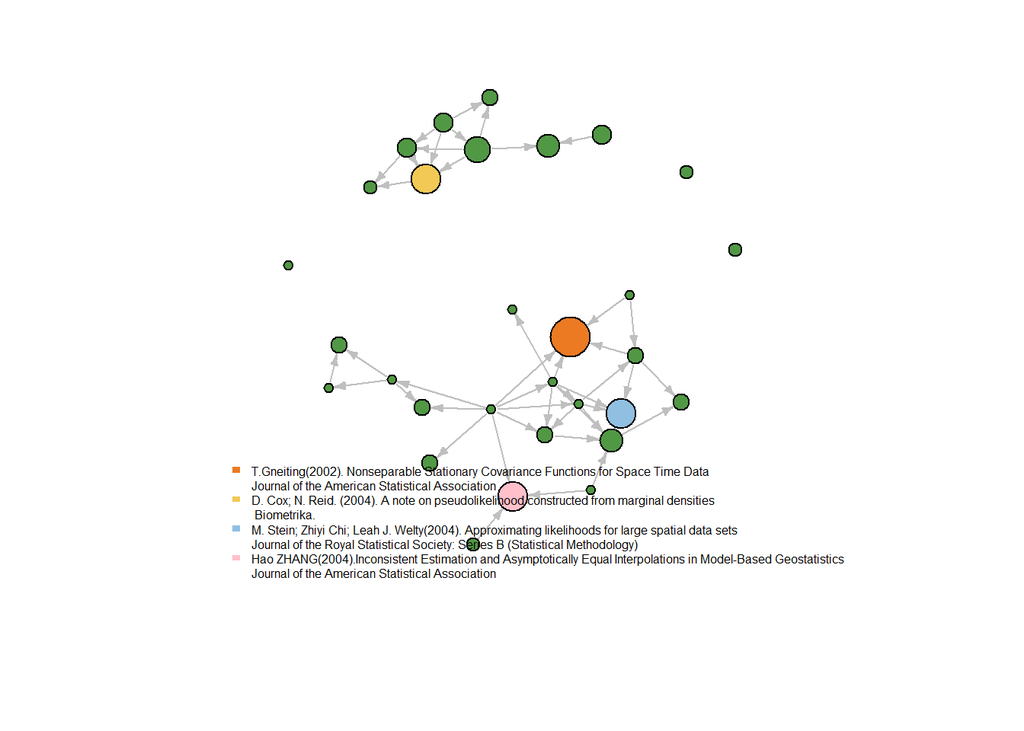

```r
# 绘制社区19作者构成的子网络
# 筛选出入度最大的30个节点
dd_dec = degree(g_cs19,mode = "in") %>% sort(decreasing = T)
g_cs19_sub = subgraph(g_cs19,names(dd_dec)[1:30])

set.seed(300)
par(mfrow=c(1,1), mar=c(5,2,2,2))

V(g_cs19_sub)$label = ""
# 设置节点颜色
V(g_cs19_sub)$color = '#519845'
V(g_cs19_sub)$color[names(V(g_cs19_sub)) == "5341"] ='#EC7A22'
V(g_cs19_sub)$color[names(V(g_cs19_sub)) == "2948"] ='#F1C954'
V(g_cs19_sub)$color[names(V(g_cs19_sub)) == "6321"] ='#90BFE2'
V(g_cs19_sub)$color[names(V(g_cs19_sub)) == "5145"] ='pink'

# 设置节点大小与入度成正比
V(g_cs19_sub)$size = dd_dec[names(V(g_cs19_sub))]*1.5

plot(g_cs19_sub,
     layout = layout.fruchterman.reingold,              # 绘制力导向布局图
     edge.arrow.size = 0.4,                             # 设置箭头大小
     edge.color = 'grey75'                              # 设置边的颜色
)


legend(x = -1.3, y = -0.6,legend = c("T.Gneiting(2002). Nonseparable Stationary Covariance Functions for Space Time Data", "Journal of the American Statistical Association","D. Cox; N. Reid. (2004). A note on pseudolikelihood constructed from marginal densities ",
" Biometrika.","M. Stein; Zhiyi Chi; Leah J. Welty(2004). Approximating likelihoods for large spatial data sets  ",
"Journal of the Royal Statistical Society: Series B (Statistical Methodology) ","Hao ZHANG(2004).Inconsistent Estimation and Asymptotically Equal Interpolations in Model-Based Geostatistics","Journal of the American Statistical Association"), fill = c('#EC7A22','#FFFFFF','#F1C954','#FFFFFF','#90BFE2','#FFFFFF','pink','#FFFFFF'), border = F, bty = "n",cex =0.5)
```

## 3 统计四大综合计量分析

对数据进行预处理

```r
library(dplyr)
data<-read.csv("allpaper.csv",header=T)
data<-data[,c("Authors",
"Article.Title",
"Source.Title",
"Author.Keywords",
"Cited.Reference.Count",
"Times.Cited..All.Databases","Publication.Year")]

#去除非法字符
colnames(data)<-c("authors","title","journal","keyword","refnum","citnum","year")
data$authors <- data$authors %>%
  iconv(from = "UTF-8", to = "ASCII//TRANSLIT", sub = "") %>%
  trimws()
```

下面统计了2000年以来的统计四大引用数前20的文章：

```r
library(stringr)
library(dplyr)

top20_papers <- data %>%
  # 按被引量降序排列
  arrange(desc(citnum)) %>%
  # 取前20行
  head(20) %>%
  mutate(across(c(title, authors), ~str_trunc(., 60))) %>%
  mutate(Rank = row_number(), .before = title) %>%
  select(Rank, title, authors, journal, year, citnum)

knitr::kable(
  top20_papers,
  col.names = c("排名", "标题", "作者", "期刊", "年份", "被引量"),
  align = c("c", "l", "l", "l", "c", "c")  # 设置列对齐
)
```

| 排名 | 标题 | 作者 | 期刊 | 年份 | 被引量 |
| --- | --- | --- | --- | --- | --- |
| 1 | Greedy function approximation: A gradient boosting machine | Friedman, JH | ANNALS OF STATISTICS | 2001 | 20179 |
| 2 | Regularization and variable selection via the elastic net | Zou, H; Hastie, T | JOURNAL OF THE ROYAL STATISTICAL SOCIETY SERIES B-STATISTICAL METHODOLOGY | 2005 | 14572 |
| 3 | Bayesian measures of model complexity and fit | Spiegelhalter, DJ; Best, NG; Carlin, BR; van der Linde, A | JOURNAL OF THE ROYAL STATISTICAL SOCIETY SERIES B-STATISTICAL METHODOLOGY | 2002 | 10750 |
| 4 | The control of the false discovery rate in multiple testi… | Benjamini, Y; Yekutieli, D | ANNALS OF STATISTICS | 2001 | 8819 |
| 5 | Least angle regression | Efron, B; Hastie, T; Johnstone, I; Tibshirani, R | ANNALS OF STATISTICS | 2004 | 7489 |
| 6 | Variable selection via nonconcave penalized likelihood an… | Fan, JQ; Li, RZ | JOURNAL OF THE AMERICAN STATISTICAL ASSOCIATION | 2001 | 7452 |
| 7 | The adaptive lasso and its oracle properties | Zou, H | JOURNAL OF THE AMERICAN STATISTICAL ASSOCIATION | 2006 | 6031 |
| 8 | Fast stable restricted maximum likelihood and marginal li… | Wood, SN | JOURNAL OF THE ROYAL STATISTICAL SOCIETY SERIES B-STATISTICAL METHODOLOGY | 2011 | 5726 |
| 9 | Additive logistic regression: A statistical view of boosting | Friedman, J; Hastie, T; Tibshirani, R | ANNALS OF STATISTICS | 2000 | 5014 |
| 10 | A direct approach to false discovery rates | Storey, JD | JOURNAL OF THE ROYAL STATISTICAL SOCIETY SERIES B-STATISTICAL METHODOLOGY | 2002 | 4830 |
| 11 | Estimating the number of clusters in a data set via the g… | Tibshirani, R; Walther, G; Hastie, T | JOURNAL OF THE ROYAL STATISTICAL SOCIETY SERIES B-STATISTICAL METHODOLOGY | 2001 | 4579 |
| 12 | Testing the number of components in a normal mixture | Lo, YT; Mendell, NR; Rubin, DB | BIOMETRIKA | 2001 | 4157 |
| 13 | Approximate Bayesian inference for latent Gaussian models… | Rue, H; Martino, S; Chopin, N | JOURNAL OF THE ROYAL STATISTICAL SOCIETY SERIES B-STATISTICAL METHODOLOGY | 2009 | 3822 |
| 14 | Synthetic Control Methods for Comparative Case Studies: E… | Abadie, A; Diamond, A; Hainmueller, J | JOURNAL OF THE AMERICAN STATISTICAL ASSOCIATION | 2010 | 3636 |
| 15 | Strictly proper scoring rules, prediction, and estimation | Gneiting, T; Raftery, AE | JOURNAL OF THE AMERICAN STATISTICAL ASSOCIATION | 2007 | 3562 |
| 16 | Model-based clustering, discriminant analysis, and densit… | Fraley, C; Raftery, AE | JOURNAL OF THE AMERICAN STATISTICAL ASSOCIATION | 2002 | 3288 |
| 17 | Bayesian calibration of computer models | Kennedy, MC; O’Hagan, A | JOURNAL OF THE ROYAL STATISTICAL SOCIETY SERIES B-STATISTICAL METHODOLOGY | 2001 | 3227 |
| 18 | NEARLY UNBIASED VARIABLE SELECTION UNDER MINIMAX CONCAVE … | Zhang, CH | ANNALS OF STATISTICS | 2010 | 3223 |
| 19 | Variational Inference: A Review for Statisticians | Blei, DM; Kucukelbir, A; McAuliffe, JD | JOURNAL OF THE AMERICAN STATISTICAL ASSOCIATION | 2017 | 3222 |
| 20 | High-dimensional graphs and variable selection with the L… | Meinshausen, N; Bhlmann, P | ANNALS OF STATISTICS | 2006 | 2897 |

### 3.1 高引作者研究

#### 3.1.1 高引作者排名

我们先来统计一下总引用量排名前20的作者：

```r
library(dplyr)
library(stringr)
library(tidyr)

top20_authors <- data %>%
  # 拆分包含多个作者的行
  separate_rows(authors, sep = ";\\s*") %>%
  # 去除首尾空格
  mutate(author = str_trim(authors)) %>%
  # 按作者分组统计总被引
  group_by(author) %>%
  summarise(total_citations = sum(citnum, na.rm = TRUE)) %>%
  # 降序排列并取前20
  arrange(desc(total_citations)) %>%
  head(20) %>%
  # 添加排名
  mutate(Rank = row_number(), .before = author)

knitr::kable(
  top20_authors,
  col.names = c("排名", "作者", "总被引量"),
  align = c("c", "l", "r")  # 对齐方式：居中、左对齐、右对齐
)
```

| 排名 | 作者 | 总被引量 |
| --- | --- | --- |
| 1 | Hastie, T | 35417 |
| 2 | Tibshirani, R | 27746 |
| 3 | Zou, H | 25959 |
| 4 | Fan, JQ | 23585 |
| 5 | Friedman, JH | 20908 |
| 6 | Li, RZ | 14485 |
| 7 | Benjamini, Y | 13038 |
| 8 | Efron, B | 12454 |
| 9 | Wood, SN | 12363 |
| 10 | Yekutieli, D | 11940 |
| 11 | Best, NG | 11367 |
| 12 | Spiegelhalter, DJ | 11260 |
| 13 | van der Linde, A | 11260 |
| 14 | Raftery, AE | 10911 |
| 15 | Carlin, BR | 10852 |
| 16 | Bhlmann, P | 9817 |
| 17 | Storey, JD | 9463 |
| 18 | Hall, P | 8044 |
| 19 | Rubin, DB | 7903 |
| 20 | Johnstone, I | 7619 |

**加权作者影响力统计**

为了更准确地衡量作者在引文网络中的实际贡献，我们计算了每位作者的加权总被引量（Weighted Citations）。与传统的总被引量不同，加权总被引量将每篇论文的引用次数按照作者人数进行平分，避免多人合作论文中引用被重复计入的问题。

具体而言，若一篇论文被引用了 C 次，且有 N 位作者，则每位作者分配到的加权被引量为 C/N。我们在此基础上，对每位作者在全部论文中的加权被引量求和，并统计其参与的文章总数。

下表展示了加权总被引量最高的前 20 位作者：

```r
library(dplyr)
library(stringr)
library(tidyr)

# 生成加权作者总被引量前二十名
top20_weighted_authors <- data %>%
  # 在拆分前计算每篇文章的作者数量
  mutate(
    authors = str_trim(authors),           # 清理前后空格
    num_authors = str_count(authors, ";") + 1  # 计算作者数
  ) %>%
  # 拆分作者列（按分号+空格分隔）
  separate_rows(authors, sep = ";\\s*") %>%
  # 再次清理拆分后的单个作者名
  mutate(
    author = str_trim(authors)             # 确保无残留空格
  ) %>%
  # 计算加权被引量
  mutate(
    weighted_cit = citnum / num_authors    # 按作者数分配
  ) %>%
  # 按作者分组统计
  group_by(author) %>%
  summarise(
    total_weighted_cit = sum(weighted_cit, na.rm = TRUE),
    total_articles = n()                   # 参与的文章总数
  ) %>%
  # 排序并取前20
  arrange(desc(total_weighted_cit)) %>%
  head(20) %>%
  mutate(
    Rank = row_number(),
    total_weighted_cit = round(total_weighted_cit, 1)
  ) %>%
  select(Rank, author, total_weighted_cit, total_articles)

knitr::kable(
  top20_weighted_authors,
  col.names = c("排名", "作者", "加权总被引", "参与文章数"),
  align = c("c", "l", "r", "r")
)
```

| 排名 | 作者 | 加权总被引 | 参与文章数 |
| --- | --- | --- | --- |
| 1 | Friedman, JH | 20486.3 | 5 |
| 2 | Zou, H | 15665.9 | 30 |
| 3 | Hastie, T | 13585.5 | 22 |
| 4 | Wood, SN | 11320.0 | 16 |
| 5 | Fan, JQ | 10263.8 | 119 |
| 6 | Tibshirani, R | 9444.0 | 37 |
| 7 | Storey, JD | 7620.4 | 7 |
| 8 | Li, RZ | 6353.6 | 56 |
| 9 | Benjamini, Y | 6284.3 | 14 |
| 10 | Efron, B | 5714.5 | 29 |
| 11 | Yekutieli, D | 5652.5 | 6 |
| 12 | Raftery, AE | 4936.5 | 25 |
| 13 | Zhang, CH | 4889.3 | 38 |
| 14 | Bhlmann, P | 4294.6 | 39 |
| 15 | Gneiting, T | 4040.0 | 16 |
| 16 | Rubin, DB | 4011.8 | 25 |
| 17 | Hall, P | 3505.8 | 142 |
| 18 | Meinshausen, N | 3297.5 | 19 |
| 19 | O’Hagan, A | 3176.4 | 9 |
| 20 | Yuan, M | 2867.0 | 35 |

#### 3.1.2 h-idex研究

为更全面衡量作者的学术影响力，本文在统计总被引量的基础上，引入了 h-index（又称 h 指数）作为补充指标。h-index 是由物理学家 Jorge E. Hirsch 于 2005 年提出的量化研究人员学术产出与影响力的综合性指标，其定义如下：

一位学者的 h-index 是指其发表的 h 篇论文中，每篇论文至少被引用 h 次。

与总被引量相比，h-index 更能平衡数量与影响力，避免因极少数高被引论文拉高整体评价，也可有效过滤大量低被引论文带来的“水涨船高”效应。因此，在文献计量分析中，h-index 常作为学者影响力排名、科研评估与资源分配的重要依据。

下文将展示四大统计期刊引用网络中，h-index 排名前 20 的高影响力作者。

```r
library(dplyr)
library(stringr)
library(tidyr)

# 拆分每行的作者
author_articles <- data %>%
  separate_rows(authors, sep = ";\\s*") %>%
  mutate(author = str_trim(authors)) %>%
  select(author, citnum)

# 定义一个函数来计算 h-index
calc_h_index <- function(citations) {
  sorted_cites <- sort(citations, decreasing = TRUE)
  h <- sum(sorted_cites >= seq_along(sorted_cites))
  return(h)
}

# 对每位作者计算 h-index 和总被引量
author_stats <- author_articles %>%
  group_by(author) %>%
  summarise(
    h_index = calc_h_index(citnum),
    total_citations = sum(citnum, na.rm = TRUE),
    n_articles = n()
  ) %>%
  arrange(desc(h_index)) %>%
  mutate(Rank = row_number(), .before = author)

top20_authors <- head(author_stats, 20)

# 表格展示
knitr::kable(
  top20_authors,
  col.names = c("排名", "作者", "h-index", "总被引量", "文章数"),
  align = c("c", "l", "c", "r", "r")
)
```

| 排名 | 作者 | h-index | 总被引量 | 文章数 |
| --- | --- | --- | --- | --- |
| 1 | Fan, JQ | 60 | 23585 | 119 |
| 2 | Hall, P | 47 | 8044 | 142 |
| 3 | Cai, TT | 44 | 6715 | 99 |
| 4 | Carroll, RJ | 39 | 5300 | 83 |
| 5 | Dunson, DB | 35 | 4315 | 86 |
| 6 | Mller, HG | 34 | 5654 | 60 |
| 7 | Wasserman, L | 33 | 5643 | 48 |
| 8 | Li, RZ | 32 | 14485 | 56 |
| 9 | Cook, RD | 28 | 2838 | 39 |
| 10 | Wang, L | 28 | 3203 | 44 |
| 11 | Lin, DY | 27 | 4255 | 38 |
| 12 | Robins, JM | 27 | 2894 | 38 |
| 13 | Dette, H | 26 | 1836 | 64 |
| 14 | He, XM | 26 | 2673 | 40 |
| 15 | Ibrahim, JG | 26 | 2573 | 46 |
| 16 | Rosenbaum, PR | 26 | 2490 | 48 |
| 17 | Zhu, HT | 26 | 2458 | 47 |
| 18 | Bhlmann, P | 25 | 9817 | 39 |
| 19 | Li, B | 25 | 3294 | 41 |
| 20 | Lin, XH | 25 | 2173 | 34 |

### 3.2 关键词研究

我们将关键词分为两大指标维度：

**热度**：关键词在统计四大期刊中出现的频率，表示在统计核心圈内被讨论的程度。

**影响力**：关键词对应文章的总被引次数，表示该领域成果对外部学术界的辐射力。

#### 3.2.1 关键词热度研究

```r
library(dplyr)
library(stringr)
library(tidyr)

# 统计关键词出现次数前 20 名
top20_keyword_freq <- data %>%
  separate_rows(keyword, sep = ";\\s*") %>%
  mutate(
    keyword = str_trim(keyword),
    keyword = str_to_lower(keyword)
  ) %>%
  filter(keyword != "") %>%  # 排除空字符串
  group_by(keyword) %>%
  summarise(n_articles = n()) %>%
  arrange(desc(n_articles)) %>%
  slice_head(n = 20) %>%
  mutate(Rank = row_number(), .before = keyword) %>%
  mutate(keyword = str_trunc(keyword, width = 30))
# 输出表格
knitr::kable(
  top20_keyword_freq,
  col.names = c("排名", "关键词", "出现次数"),
  align = c("c", "l", "r"),
  format.args = list(big.mark = ",")
)
```

| 排名 | 关键词 | 出现次数 |
| --- | --- | --- |
| 1 | markov chain monte carlo | 227 |
| 2 | causal inference | 213 |
| 3 | model selection | 213 |
| 4 | nonparametric regression | 208 |
| 5 | variable selection | 198 |
| 6 | bootstrap | 195 |
| 7 | sparsity | 193 |
| 8 | lasso | 153 |
| 9 | consistency | 148 |
| 10 | false discovery rate | 138 |
| 11 | functional data analysis | 128 |
| 12 | missing data | 127 |
| 13 | dimension reduction | 124 |
| 14 | multiple testing | 122 |
| 15 | asymptotic normality | 118 |
| 16 | em algorithm | 113 |
| 17 | bayesian inference | 106 |
| 18 | survival analysis | 104 |
| 19 | robustness | 103 |
| 20 | classification | 101 |

我们来看一下排名前列的几个关键词出现次数随年份的趋势：

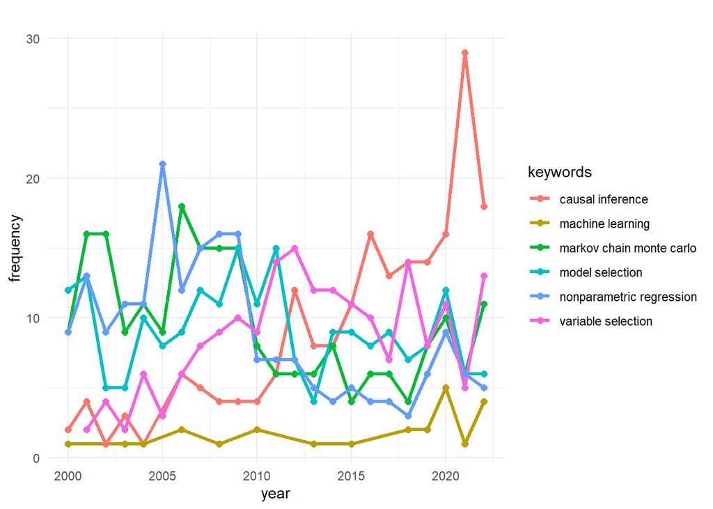

```r
library(dplyr)
library(tidyr)
library(stringr)
library(ggplot2)

keyword_year_freq <- data %>%
  separate_rows(keyword, sep = ";\\s*") %>%
  mutate(
    keyword = str_trim(keyword),
    keyword = str_to_lower(keyword)
  ) %>%
  group_by(keyword, year) %>%
  summarise(n_articles = n(), .groups = "drop") %>%
  filter(year <= 2022)  # 截断到2022年

# 指定要观察的关键词
target_keywords <- c("machine learning", "nonparametric regression", "causal inference","model selection","variable selection","markov chain monte carlo")

keyword_year_freq %>%
  filter(keyword %in% target_keywords) %>%
  ggplot(aes(x = year, y = n_articles, color = keyword)) +
  geom_line(size = 1.2) +
  geom_point(size = 2) +
  labs(
    title = "keywords frequency（2000-2024）",
    x = "year",
    y = "frequency",
    color = "keywords"
  ) +
  theme_minimal()
```

现在我们来统计一下出现次数>150的关键词随时间每年出现次数的变化

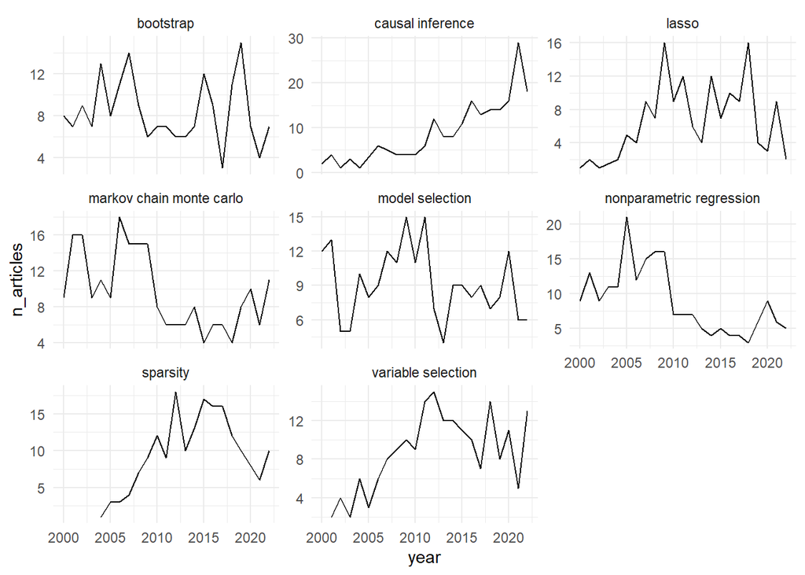

```r
library(ggplot2)
library(forcats)
# 计算关键词总出现次数
top_keywords <- data %>%
  separate_rows(keyword, sep = ";\\s*") %>%
  mutate(keyword = str_trim(keyword), keyword = str_to_lower(keyword)) %>%
  filter(keyword != "") %>%   # 删除空关键词
  count(keyword, sort = TRUE) %>%
  filter(n >= 150)


top_keyword_list <- top_keywords$keyword
keyword_year_freq %>%
  filter(keyword %in% top_keyword_list, year <= 2024) %>%
  ggplot(aes(x = year, y = n_articles)) +
  geom_line() +
  facet_wrap(~ keyword, scales = "free_y") +
  theme_minimal()
```

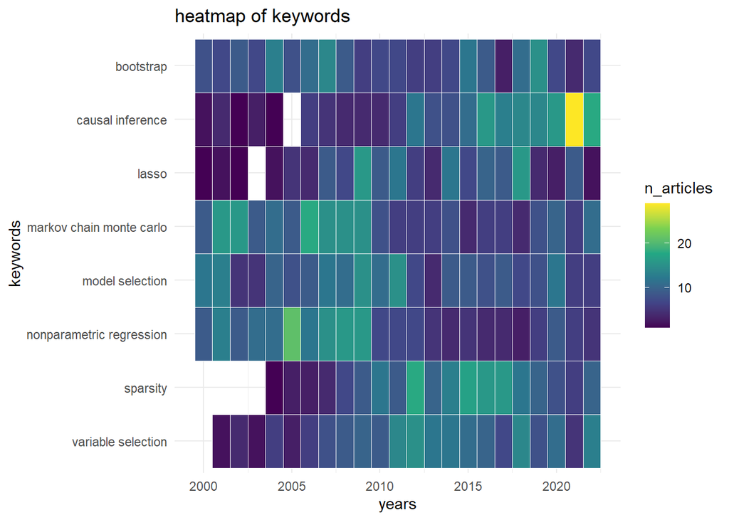

```r
heatmap_data <- keyword_year_freq %>%
  filter(keyword %in% head(top_keyword_list, 20), year <= 2024)

ggplot(heatmap_data, aes(x = year, y = fct_rev(keyword), fill = n_articles)) +
  geom_tile(color = "white") +
  scale_fill_viridis_c() +
  labs(title = "heatmap of keywords", x = "years", y = "keywords") +
  theme_minimal()
```

#### 3.2.2 关键词影响力研究

```r
library(dplyr)
library(stringr)
library(tidyr)  # 用于拆分关键词列

### 生成关键词总被引量前十名
top10_keyword <- data %>%
  # 拆分关键词列
  separate_rows(keyword, sep = ";\\s*") %>%
  # 清洗关键词
  mutate(
    keyword = str_trim(keyword),
    keyword = str_to_lower(keyword)
  ) %>%
  # 按关键词分组统计总被引
  group_by(keyword) %>%
  summarise(total_citations = sum(citnum, na.rm = TRUE)) %>%
  # 降序排列并取前20
  arrange(desc(total_citations)) %>%
  head(20) %>%
  # 添加排名
  mutate(Rank = row_number(), .before = keyword)

knitr::kable(
  top10_keyword,
  col.names = c("排名", "关键词", "总被引量"),
  align = c("c", "l", "r"),
  format.args = list(big.mark = ",")
)
```

| 排名 | 关键词 | 总被引量 |
| --- | --- | --- |
| 1 | lasso | 69,065 |
| 2 | variable selection | 57,900 |
| 3 | model selection | 36,709 |
| 4 | boosting | 31,041 |
| 5 | sparsity | 22,827 |
| 6 | markov chain monte carlo | 22,386 |
| 7 | function estimation | 20,356 |
| 8 | decision trees | 20,350 |
| 9 | robust nonparametric regression | 20,179 |
| 10 | causal inference | 19,438 |
| 11 | linear regression | 18,784 |
| 12 | nonparametric regression | 18,656 |
| 13 | penalization | 17,776 |
| 14 | false discovery rate | 17,654 |
| 15 | asymptotic normality | 16,180 |
| 16 | lars algorithm | 15,489 |
| 17 | classification | 15,140 |
| 18 | penalized likelihood | 15,084 |
| 19 | grouping effect | 14,629 |
| 20 | p >> n problem | 14,572 |

**第一类：内外兼修型**（高热度 × 高引用） 示例：lasso（出现153次，被引69,065次）、variable selection、model selection

特征：在四大统计期刊中频繁出现，同时对应文献被广泛引用，说明这些关键词代表的是理论与应用并重的核心统计主题。

**第二类：内部热门型**（高热度 × 中等或低引用） 示例：bootstrap、missing data、classification

特征：这些话题在统计学内部被高度关注，但其外部引用影响相对较弱，反映出统计学界内部的重要基础性问题。

**第三类：外部热门型**（低热度 × 高引用） 示例：boosting、decision trees

特征：这类方法在四大中出现频率较低，但对应文章被广泛引用，反映出它们在机器学习、人工智能等统计交叉领域的巨大影响力。

### 3.3 期刊研究

在本节中，我们对统计四大期刊（JASA、JRSSB、AoS、Biometrika）自2000年至2022年的发文数量与影响力演变进行可视化分析。首先，通过年度发文量趋势图，我们观察各期刊的研究产出变化，为期刊活跃度与学科关注度提供宏观视角。其次，为更公平比较不同年份文章的引用表现，我们将每年总被引量除以“至2025年的年数”，得到年均被引量指标。该标准化方法有效控制发表时间对引用积累的影响，更真实地反映不同时期论文的平均影响力趋势。

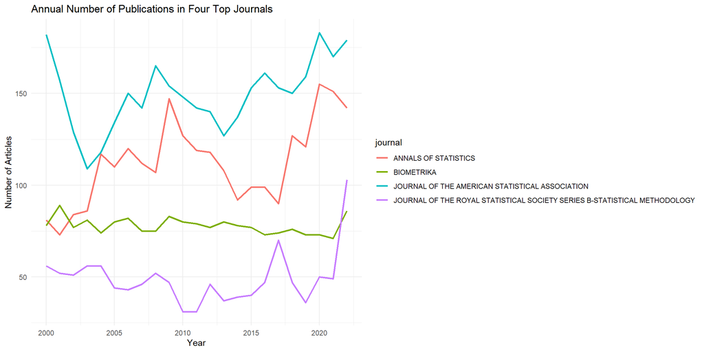

```r
library(dplyr)
library(ggplot2)

# 统计每年每刊发文量和总被引量
journal_year_trend <- data %>%
  filter(year >= 2000, year <= 2022) %>%
  group_by(journal, year) %>%
  summarise(n_articles = n(), total_cit = sum(citnum, na.rm = TRUE), .groups = "drop") %>%
  mutate(adjusted_cit = total_cit / (2025 - year))

# 发文量趋势图
ggplot(journal_year_trend, aes(x = year, y = n_articles, color = journal)) +
  geom_line(size = 1) +
  theme_minimal() +
  labs(  title = "Annual Number of Publications in Four Top Journals",x = "Year",y = "Number of Articles")
```

[figure not shown]

```r
# 单位时间平均被引趋势图
ggplot(journal_year_trend, aes(x = year, y = adjusted_cit, color = journal)) +
  geom_line(size = 1) +
  theme_minimal() +
  labs(
      title = "Annual Number of Publications in Four Top Journals",
    x = "Year",
    y = "Number of Articles"
  )
```

### 3.4 共同作者社区研究

为了深入理解统计学领域核心作者之间的合作关系，我们基于文献的作者信息构建了作者共现网络。在该网络中，每个节点代表一位作者，边表示至少在一篇文章中共同署名，边的权重表示合作频次。

我们采用 Louvain 社区发现算法对整个网络进行划分，挖掘具有高度内部连接的作者群体（即“社区”）。这一方法能够有效识别研究子领域中的作者团体、学术合作圈及潜在的研究流派。

```r
library(igraph)
library(dplyr)
library(stringr)
library(tidyr)
data <- data %>%
  mutate(author_list = str_split(authors, ";"))

edges_list <- list()
for (i in 1:nrow(data)) {
  authors_i <- unlist(data$author_list[i])
  authors_i <- trimws(authors_i)
  if (length(authors_i) > 1) {
    coauthor_pairs <- combn(authors_i, 2, simplify = FALSE)
    edges_list <- append(edges_list, coauthor_pairs)
  }
}
edges_df <- do.call(rbind, lapply(edges_list, function(x) data.frame(from = x[1], to = x[2])))
edges_weighted <- edges_df %>%
  group_by(from, to) %>%
  summarise(weight = n(), .groups = "drop")

g <- graph_from_data_frame(edges_weighted, directed = FALSE)
g <- simplify(g, edge.attr.comb = list(weight = "sum"))
set.seed(1234)
comm <- cluster_louvain(g)
comm_sizes <- sizes(comm)
sorted_comm_ids <- order(comm_sizes, decreasing = TRUE)
```

为增强可视化效果，我们选择了若干典型社区，分别绘制其子图。每个子图中：

节点大小表示作者在社区内的合作活跃度（即度数）；

颜色突出了该社区内最具影响力的前五位作者；

采用数字编号替代标签，避免图中信息重叠；

图例展示了这些编号作者的姓名，方便解读。

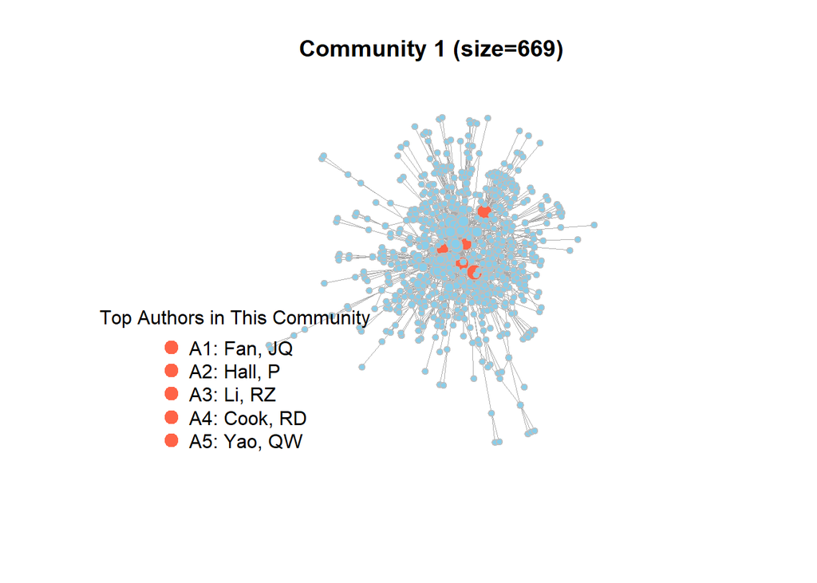

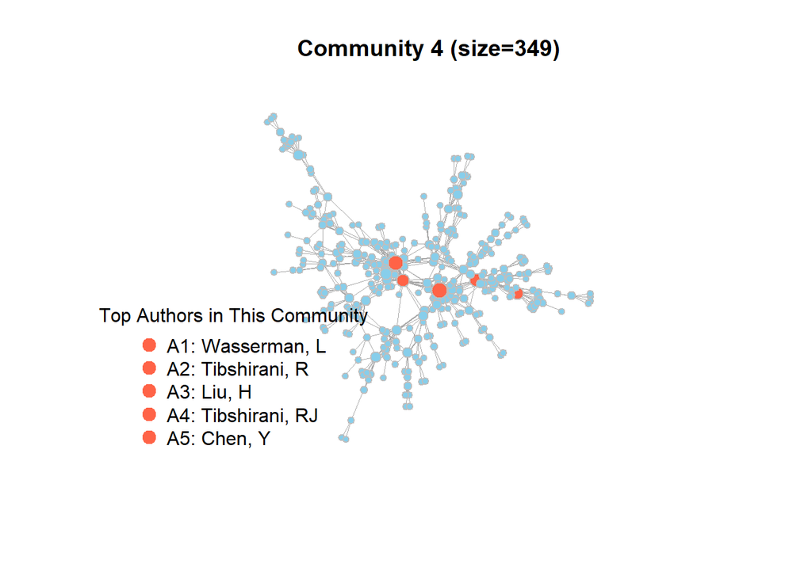

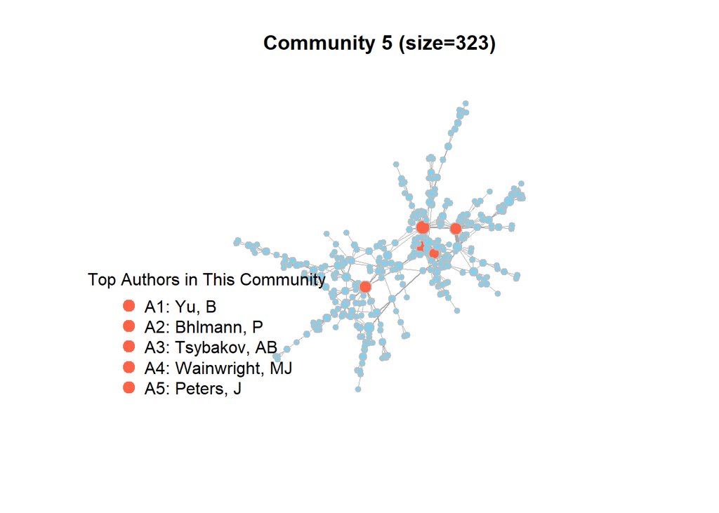

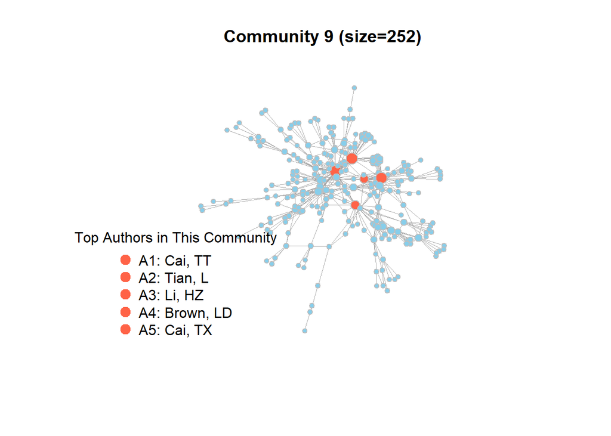

```r
for (k in c(1,4,5,9)) {
#选择第k大社区

comm_id <- sorted_comm_ids[k]
nodes_in_comm <- which(membership(comm) == comm_id)
subg <- induced_subgraph(g, vids = nodes_in_comm)

# 提取该社区前5个最活跃作者
deg <- degree(subg)
top_authors <- names(sort(deg, decreasing = TRUE))[1:5]
top_ids <- match(top_authors, V(subg)$name)

set.seed(1234)
layout1 <- layout_with_fr(subg)
V(subg)$size <- 4 + 6 * (deg / max(deg))
V(subg)$color <- "skyblue"
V(subg)$frame.color <- "gray"
V(subg)$label <- NA
V(subg)$label.cex <- 0.7

# 给前5个作者编号
author_labels <- paste0("A", 1:5)
V(subg)$label <- NA
V(subg)$color[top_ids] <- "tomato"

plot(subg,
     layout = layout1,
     vertex.size = V(subg)$size,
     vertex.label = NA,
     edge.width = E(subg)$weight / max(E(subg)$weight) * 4,
     main = paste0("Community ", k, " (size=", length(nodes_in_comm), ")"))

# 添加编号标签
for (i in 1:5) {
  text(layout1[top_ids[i], 1],
       layout1[top_ids[i], 2] + 0.03,
       labels = author_labels[i],
       col = "black", cex = 0.8, font = 2)
}
legend("bottomleft",
       legend = paste0(author_labels, ": ", top_authors),
       col = "tomato",
       pch = 19,
       pt.cex = 1.5,
       bty = "n",
       title = "Top Authors in This Community")
}
```

在社区可视化分析中我们发现：同一社区内的作者往往研究方向相近，且不少人之间存在明显的学术传承关系，如师生、师门或长期合作团队。这种结构性反映了领域内部的合作惯性与知识传播路径。

通过这种方式，我们不仅能够从宏观上观察学术合作的结构性特征，还能识别各研究子领域中的关键作者和合作核心，为后续的引文分析与学术影响力评价提供基础。

## 4 总结

本文系统分析了统计学四大顶刊（JASA、JRSSB、AoS、Biometrika）的学术引文网络及其相关计量特征，主要工作和结论如下：

**引文网络结构分析** 通过构建四大期刊的引文网络，揭示了整体网络的稠密程度、连通片数量及节点度分布。结果显示，统计学顶刊的引文网络具有较高的连通性和明显的幂律度分布特征，表明少数高被引文献在学科传播中起着核心作用。

**社区结构发现** 利用社区检测方法识别了多个学术子领域或研究群体，反映了统计学不同研究主题或方法的聚类特征，为理解学科内部结构和发展动态提供了新的视角。

**研究意义与展望** 本文的多维度分析不仅有助于全面理解统计学顶尖期刊的学术生态，也为学科发展、研究热点追踪及人才培养提供数据支持。未来可结合更多数据源和动态分析，进一步探索统计学知识传播的新趋势和深层次结构。

**改进与未来工作**

1.数据时效性有待提升。当前分析基于2000-2022年的已有数据集，未来应引入最新数据，尤其考虑近几年统计学领域的新兴主题和动态变化。

2.网络分析指标可进一步丰富。除当前所用的中心性和路径指标外，可尝试更多复杂网络度量（如动力学演化、层级结构等）以揭示更深层次特征。